# Introduction

Hello! In this Vignette you will find how to convert FragPipe output to TPP-R (and if needed, TP-MAP) input.

## What is Thermal Protein Profiling (TPP)?

TPP is an unbiased method to search for drug targets by monitoring protein stability in the presence and absence of the drug compound of interest. Different samples at different temperatures are prepared and them label with [Tandem Mass Tags (TMT)](https://pubs.acs.org/doi/10.1021/ac0262560). Next, samples are pooled together and analyzed by typical mass spectrometry-based proteomics. In the links below users ar encouraged to review the Nature Protocol method and a recent overview of TPP to understand how the data is analyzed and how protein melting curves are obtained.

- 2015 [Nature Methods TPP protocol](https://www.nature.com/articles/nprot.2015.101)
- Recent [small overview](https://pubmed.ncbi.nlm.nih.gov/36368297/)
- Data use in this package was analyzed by FragPipe. Raw data was obtained from [a TPP study](https://www.nature.com/articles/s41467-019-09107-y), where the effects of ATP in protein solubility were determined.

Comparing a protein melting curve with and without drug is important to determine if the compound had a destabilizing effect on the protein (melting temperature decrease) or the opposite stabilizing effect (melting temperature increase) or none.

## What is FragPipe?

- It is a set of computation tools capable of protein identification and quantification from bottom-up proteomics data. One of its modules is capable of analyzing TMT datasets, such as the one produced in TPP experiments. FragPipe is a very fast and robust pipeline, but there are no FragPipe-compatible TPP tools (until now). To learn how to use FragPipe see the link below:
  - [FragPipe website](https://fragpipe.nesvilab.org/docs/tutorial_fragpipe_outputs.html%5D)
- For downstream TPP analysis of FragPipe data, this package makes it possible to use both TPP-R and TP-MAP.

## What is TPP-R?

It is an R package available through Bioconductor capable of analyzing both 1D (temperature change) and 2D (temperate and drug concentration changes) TPP datasets. It produces melting curves for each protein as well as metrics on the fittings of the curves. For more details see the link below:

- [TPP-R at Bioconductor](https://bioconductor.org/packages/release/bioc/html/TPP.html)

## What is TP-MAP?

It is a GUI-based TPP analysis program also available for both 1DTPP and 2DTPP data. Melting curves (1DTPP) or matrices (2DTPP) can be visualized in TP-MAP. protein-protein interactions analysis using STRING are also possible. for more information visit:

- [2022 bioRxiv](https://www.biorxiv.org/content/10.1101/2021.02.22.432361v2)

### Package Installation

Use: install.packages(“FragPipeToTPPR”) if package has not been installed.

There are three functions to use

- **tmitotppr** (FragPipe to TPP-R)
- **tpprNormOneDTPP** (TPPR all melting curve normalization only - required to input 1DTPP data into TP-MAP)
- **tpprTotpmap** (from TPP-R normalized FragPipe data to TP-MAP input file)

Below we will go through two different workflows where the functions above will be used.

### From FragPipe to TP-MAP

```r
library(FragPipeToTPPR, TPP)
```

3. Create two variables: the path to your FragPipe output folder and a vector with the desired labels used in your experiment.

```r
FPpath <- FragPipeToTPPR::dummyFragPipepath
```

Labels used in experiment e.g. Vehicle vs Treatment, Control vs Sample.

```r
explabels <- FragPipeToTPPR::dummyexplabels
```

```r
configpath <- FragPipeToTPPR::tmtitotppr(FPpath, explabels)
```

```
#> [1] "data.frame"
#> [[1]]
#> [[1]]$Index
#> [1] "Prot_ID"
#>
#> [[1]]$NumberPSM
#> [1] "qssm"
#>
#> [[1]]$`37_Treatment_1`
#> [1] "rel_fc_126"
#>
#> [[1]]$`40.4_Treatment_1`
#> [1] "rel_fc_127L"
#>
#> [[1]]$`44_Treatment_1`
#> [1] "rel_fc_127H"
#>
#> [[1]]$`46.9_Treatment_1`
#> [1] "rel_fc_128L"
#>
#> [[1]]$`49.8_Treatment_1`
#> [1] "rel_fc_128H"
#>
#> [[1]]$`52.9_Treatment_1`
#> [1] "rel_fc_129L"
#>
#> [[1]]$`55.5_Treatment_1`
#> [1] "rel_fc_129H"
#>
#> [[1]]$`58.6_Treatment_1`
#> [1] "rel_fc_130L"
#>
#> [[1]]$`62_Treatment_1`
#> [1] "rel_fc_130H"
#>
#> [[1]]$`66.3_Treatment_1`
#> [1] "rel_fc_131L"
#>
#>
#> [[2]]
```

[output cut: 233 more lines]

```
#>
#> [[2]]$`129H`
#> [1] 55.5
#>
#> [[2]]$`130L`
#> [1] 58.6
#>
#> [[2]]$`130H`
#> [1] 62
#>
#> [[2]]$`131L`
#> [1] 66.3
#>
#>
#> [1] "Saving results in 1DTPP-TPPR folder"
```

The results are now saved in the newly created folder 1DTPP-TPPR. If you explore inside the new folder, not only the configuration file will be present, but also .txt files compatible with TPP-R for each replicate and experiment. (**Note: The path below is a sample. When you explore YOUR FragPipe output folder you will find a 1DTPP-TPPR folder**)

```r
print(configpath)
```

```
#> [1] "C:/Users/crojaram/Documents/FragPipeToTPPR/inst/extdata/dummyFragPipeFolder/1DTPP-TPPR/TPP-TR_config.csv"
```

```r
FragPipeToTPPR::tpprNormOneDTPP(configpath,FPpath)
```

```
#>
#>  ==> PLEASE READ BEFORE PACKAGE USE:
#>      Could not locate a zip command in your path. This command is required for
#>      Excel output on Windows (see vignette).
#>      You can still use the 'TPP' package and access its results via the
#>      dataframes produced by 'analyzeTPPTR' and 'analzyeTPPCCR'.
#>      For export to Excel, please add a zip command to the path.
#> Importing data...
#> Replacing config table column 'Replicate' by corresponding columns starting with suffix 'Comparison'.
#> Comparisons will be performed between the following experiments:
#> Treatment_1_vs_Vehicle_1
#> Treatment_2_vs_Vehicle_2
#>
#> The following valid label columns were detected:
#> 126, 127L, 127H, 128L, 128H, 129L, 129H, 130L, 130H, 131L.
#>
#> Importing TR dataset: Treatment_1
#> Removing duplicate identifiers using quality column 'qupm'...
#> 4 out of 4 rows kept for further analysis.
#>   -> Treatment_1 contains 4 proteins.
#>   -> 3 out of 4 proteins (75%) suitable for curve fit (criterion: > 2 valid fold changes per protein).
#>
#> Importing TR dataset: Treatment_2
#> Removing duplicate identifiers using quality column 'qupm'...
#> 4 out of 4 rows kept for further analysis.
#>   -> Treatment_2 contains 4 proteins.
#>   -> 3 out of 4 proteins (75%) suitable for curve fit (criterion: > 2 valid fold changes per protein).
#>
#> Importing TR dataset: Vehicle_1
#> Removing duplicate identifiers using quality column 'qupm'...
#> 4 out of 4 rows kept for further analysis.
#>   -> Vehicle_1 contains 4 proteins.
#>   -> 4 out of 4 proteins (100%) suitable for curve fit (criterion: > 2 valid fold changes per protein).
#>
#> Importing TR dataset: Vehicle_2
#> Removing duplicate identifiers using quality column 'qupm'...
#> 4 out of 4 rows kept for further analysis.
#>   -> Vehicle_2 contains 4 proteins.
#>   -> 3 out of 4 proteins (75%) suitable for curve fit (criterion: > 2 valid fold changes per protein).
#>
```

[output cut: 35 more lines]

```
#>   Column 9 between 0 and 0.3 -> 3 out of 3 proteins passed
#>   Column 10 between 0 and 0.2 -> 3 out of 3 proteins passed
#> 1 out of 3 proteins passed in total.
#> Experiment with most remaining proteins after filtering: Treatment_2
#> -> NormP contains 1 proteins.
#> -----------------------------------
#> Computing normalization coefficients:
#> 1. Computing fold change medians for proteins in normP.
#> 2. Fitting melting curves to medians.
#> -> Experiment with best model fit: Treatment_2 (R2: 0.601)
#> 3. Computing normalization coefficients
#> Creating QC plots to illustrate median curve fits.
#> -----------------------------------
#> Normalizing all proteins in all experiments.
#> Normalization successfully completed!
```

```r
FragPipeToTPPR::tpprTotpmap(configpath,hoomandb)
```

```
#> [1] "C:/Users/crojaram/Documents/FragPipeToTPPR/inst/extdata/dummyFragPipeFolder/1DTPP-TPPR/1DTPP.tpmap.txt"
```

The tptmap.txt file (located in the 1DTPP-TTPR folder) can now be loaded in TP-MAP. Below is how the melting curve for protein A0AVT1 looks like:

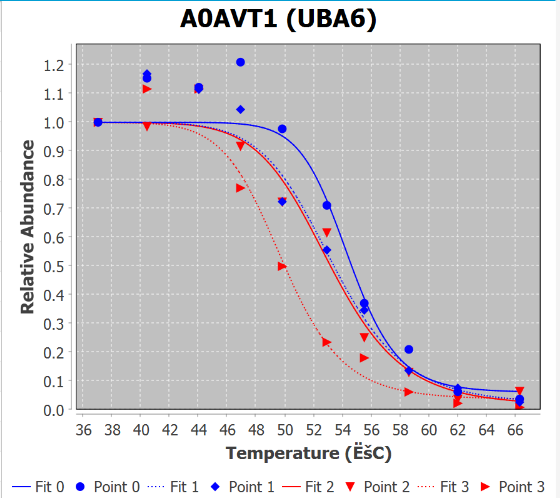

### From FragPipe to TPP-R: 1DTPP

Complete steps 1 - 4 from the **From FragPipe to TP-MAP** section. In step 5 instead of running tpprNormOneDTPP(configpath,FPpath), the full TPPR workflow function will be used. remember to use the correct configutation file path and to pass the function a directory to save the results (in this case 1DTPP-TPPR folder):

```r
TPPRfolder <- file.path(FPpath, "1DTPP-TPPR")
TPPTR_result <- TPP::analyzeTPPTR(configpath,resultPath = TPPRfolder , methods = "meltcurvefit",idVar= "Prot_ID",qualColName="qssm")
```

```
#> This is TPP version 3.30.0.
#> Importing data...
#> Replacing config table column 'Replicate' by corresponding columns starting with suffix 'Comparison'.
#> Comparisons will be performed between the following experiments:
#> Treatment_1_vs_Vehicle_1
#> Treatment_2_vs_Vehicle_2
#>
#> The following valid label columns were detected:
#> 126, 127L, 127H, 128L, 128H, 129L, 129H, 130L, 130H, 131L.
#>
#> Importing TR dataset: Treatment_1
#> Removing duplicate identifiers using quality column 'qssm'...
#> 4 out of 4 rows kept for further analysis.
#>   -> Treatment_1 contains 4 proteins.
#>   -> 3 out of 4 proteins (75%) suitable for curve fit (criterion: > 2 valid fold changes per protein).
#>
#> Importing TR dataset: Treatment_2
#> Removing duplicate identifiers using quality column 'qssm'...
#> 4 out of 4 rows kept for further analysis.
#>   -> Treatment_2 contains 4 proteins.
#>   -> 3 out of 4 proteins (75%) suitable for curve fit (criterion: > 2 valid fold changes per protein).
#>
#> Importing TR dataset: Vehicle_1
#> Removing duplicate identifiers using quality column 'qssm'...
#> 4 out of 4 rows kept for further analysis.
#>   -> Vehicle_1 contains 4 proteins.
#>   -> 4 out of 4 proteins (100%) suitable for curve fit (criterion: > 2 valid fold changes per protein).
#>
#> Importing TR dataset: Vehicle_2
#> Removing duplicate identifiers using quality column 'qssm'...
#> 4 out of 4 rows kept for further analysis.
#>   -> Vehicle_2 contains 4 proteins.
#>   -> 3 out of 4 proteins (75%) suitable for curve fit (criterion: > 2 valid fold changes per protein).
#>
#> Results will be written to C:/Users/crojaram/Documents/FragPipeToTPPR/inst/extdata/dummyFragPipefolder/1DTPP-TPPR
#> Creating normalization set:
#>  1. Filtering by non fold change columns:
#> Filtering by annotation column(s) 'qssm' in treatment group: Treatment_1
#>   Column qssm between 4 and Inf-> 3 out of 4 proteins passed.
#> 3 out of 4 proteins passed in total.
```

[output cut: 64 more lines]

```
#> Results table created successfully.
#> Writing results to file: C:/Users/crojaram/Documents/FragPipeToTPPR/inst/extdata/dummyFragPipefolder/1DTPP-TPPR/results_TPP_TR.xlsx
#> File created successfully!
#> Creating QC plots to visualize median curve fits...
#> done.
#> Creating QC plots to visualize normalization effects...
#> done.
#> Creating venn diagrams...
#> Creating Venn diagram to summarize all experiments.
#> Creating Venn diagram to summarize all comparisons.
#> done.
#> Creating QC plots to visualize minimal slope distributions...
#> done.
#> Creating QC plots to visualize differences in melting points...
#> done.
```

and voila! Melting curves have been fit for each protein (see Melting_curves folder, QCPlots.pdf and results_TPP-TR.xlsx). For more information on TPP-R outputs see [package website](https://bioconductor.org/packages/release/bioc/html/TPP.html).